# Data Science Capstone - Milestone Report

Shubhendu Dash

17/08/2020

## 1) Introduction

The goal of this project is just to display that you’ve gotten used to working with the data and that you are on track to create your prediction algorithm. Please submit a report on [R Pubs](http://rpubs.com/) that explains your exploratory analysis and your goals for the eventual app and algorithm. This document should be concise and explain only the major features of the data you have identified and briefly summarize your plans for creating the prediction algorithm and Shiny app in a way that would be understandable to a non-data scientist manager. You should make use of tables and plots to illustrate important summaries of the data set. The motivation for this project is to: 1. Demonstrate that you’ve downloaded the data and have successfully loaded it in. 2. Create a basic report of summary statistics about the data sets. 3. Report any interesting findings that you amassed so far. 4. Get feedback on your plans for creating a prediction algorithm and Shiny app.

## 2) Dataset

### 2.1) Description

From the [course dataset information](https://www.coursera.org/learn/data-science-project/supplement/Iimbd/task-0-understanding-the-problem), the data comes from a corpus called *HC Corpora* (the original site is not reachable, but an archive of it can be seen at https://web-beta.archive.org/web/20160930083655/http://www.corpora.heliohost.org/aboutcorpus.html). *Corpora* are collected from publicly available sources by a web crawler.

As said before, the dataset can be downloaded from https://d396qusza40orc.cloudfront.net/dsscapstone/dataset/Coursera-SwiftKey.zip, and consists, once being downloaded and uncompressed, of 4 folders corresponding to 4 different languages (German, English, Finnish, and Russian), and each folder containing 3 files from 3 different text sources (blogs, news, and Twitter):

| # | File |
| --- | --- |
| 1 | HC Corpora/de_DE/de_DE.blogs.txt |
| 2 | HC Corpora/de_DE/de_DE.news.txt |
| 3 | HC Corpora/de_DE/de_DE.twitter.txt |
| 4 | HC Corpora/en_US/en_US.blogs.txt |
| 5 | HC Corpora/en_US/en_US.news.txt |
| 6 | HC Corpora/en_US/en_US.twitter.txt |
| 7 | HC Corpora/fi_FI/fi_FI.blogs.txt |
| 8 | HC Corpora/fi_FI/fi_FI.news.txt |
| 9 | HC Corpora/fi_FI/fi_FI.twitter.txt |
| 10 | HC Corpora/ru_RU/ru_RU.blogs.txt |
| 11 | HC Corpora/ru_RU/ru_RU.news.txt |
| 12 | HC Corpora/ru_RU/ru_RU.twitter.txt |

Next, a couple of sample lines of Twitter files are shown:

- *de_DE.twitter.txt*:

```
## [1] "irgendwas stimmt mut meinem internet am pc nich :("
## [2] "\"Wir haben hier ein angebrochenes Fass Bier!\" habe ich mir auch anders vorgestellt. Fragt sich nur, wer darÃ¼ber gekotzt hat."
## [3] "Meine Kommilitonen beschweren sich, nie Freizeit zu haben... Anscheinend mache ich was falsch. Naja. LÃ¤uft..."
```

- *en_US.twitter.txt*:

```
## [1] "How are you? Btw thanks for the RT. You gonna be in DC anytime soon? Love to see you. Been way, way too long."
## [2] "When you meet someone special... you'll know. Your heart will beat more rapidly and you'll smile for no reason."
## [3] "they've decided its more fun if I don't."
```

There exist special characters in the texts, for example, question marks. Due to that, they should be taken into account to be discarded in further cleaning data stages.

### 2.2) Dataset details

Our analysis starts with a summary table including, for each file in the bundle, file stats (size in bytes) and data derived from the execution of the *wc* command (i.e. lines and words counting, and words per line ratio):

[output not shown]

In the context of the Capstone project, only the English language files will be taken into account, that is:

[output not shown]

From this standpoint, one sees that we are going to be dealing with around *556 MB* of data. This data size could become into a very slow performance in processing the data. Because of that, a subset consisting of 1% of the original dataset can be used, as suggested in [*Task 1*](https://www.coursera.org/learn/data-science-project/supplement/IbTUL/task-1-getting-and-cleaning-the-data) of the course.

### 2.2) Dataset cleaning

Once the dataset and its details have been introduced, the following step is its cleaning. Firstly, total of text from the blog, Twitter and news files is loaded, considering the flag **skipNul = TRUE** for line reading in order to skip nulls, and the opening option ‘rb’ when reading *en_US.news.txt* so that the warning *“incomplete final line found on …”* , as suggested from [course discussion forums](https://www.coursera.org/learn/data-science-project/discussions/all/threads/ixryee4OEeW3AhKGdOu9ew/replies/6k05qu4dEeW3AhKGdOu9ew). Finished the loading task, a sampling of 1% of the data is performed.

This task resulted in an object of size *8 MB*, meaningly lesser than the original set. Next, a corpus is created from the text already sampled, using the [*tm*](https://cran.r-project.org/web/packages/tm/index.html) pacakge, in order to take advantage of the text mining functionalities provided by that package.

```
## <<VCorpus>>
## Metadata:  corpus specific: 0, document level (indexed): 0
## Content:  documents: 42695
```

The corpus has *1011562 words* approximately.

Following a sample of first 2 documents:

```
## John begins by describing Jesus as God right from the beginning. In the beginning was the Word, and the Word was with God, and the Word was God. (v 1) Word is logos, and, in this case, refers to Christ. This is evidenced by verse 14, And the Word became flesh and dwelt among us, and we have seen …
```

```
## I hope you are having a colorful, beautiful Spring.
```

The cleaning consists of several transformation tasks, namely:

- *Uniforming the text to lowercase*
- *Removing punctuation, number, special characters, etc.*
- *Striping whitespaces*
- *Removing stop words*
- *Profanity filtering (Removing swear words)*
- *Stemming the text*

Many of these task are performed using *tm* transformation operations, the rest of them need certain custom coding, usign the function *content_transformer()* from *tm* package. The transformations provided by *tm* package are:

```
## [1] "removeNumbers"     "removePunctuation" "removeWords"
## [4] "stemDocument"      "stripWhitespace"
```

#### 2.2.1) Uniforming the text to lowercase

This transformation converts the whole corpus text to lowercase, using the *tolower()* transformation. Next, the sample of first 2 documents is shown again:

```
## john begins by describing jesus as god right from the beginning. in the beginning was the word, and the word was with god, and the word was god. (v 1) word is logos, and, in this case, refers to christ. this is evidenced by verse 14, and the word became flesh and dwelt among us, and we have seen …
```

```
## i hope you are having a colorful, beautiful spring.
```

#### 2.2.2) Removing punctuation, number, special characters, etc.

In this step, for removing punctuations and numbers, the operations used are *removePunctuation()* and *removeNumbers()* For special characters and character sequences (e.g URLs, email addresses, Twitter users and hashtags, etc.), the *toSpace()* function is used (borrowed from the [*Kailash Awati’s article*](https://eight2late.wordpress.com/2015/05/27/a-gentle-introduction-to-text-mining-using-r/)).

```
## john begins by describing jesus as god right from the beginning in the beginning was the word and the word was with god and the word was god v  word is logos and in this case refers to christ this is evidenced by verse  and the word became flesh and dwelt among us and we have seen his glory glory…
```

```
## i hope you are having a colorful beautiful spring
```

#### 2.2.3) Striping whitespaces

In this transformation, multiple whitespaces are collapsed to a single blank. The operation is perfomed using the *stripWhitespace()* transformation:

```
## john begins by describing jesus as god right from the beginning in the beginning was the word and the word was with god and the word was god v word is logos and in this case refers to christ this is evidenced by verse and the word became flesh and dwelt among us and we have seen his glory glory a…
```

```
## i hope you are having a colorful beautiful spring
```

#### 2.2.4) Removing stop words

In this case, stop words (for English language) are removed. The operation to be applied is the *stopwords()* transformation:

```
## john begins  describing jesus  god right   beginning   beginning   word   word   god   word  god v word  logos    case refers  christ   evidenced  verse   word became flesh  dwelt among us    seen  glory glory     son   father full  grace  truth john packs  lot  information   short amount  writin…
```

```
##  hope     colorful beautiful spring
```

#### 2.2.5) Profanity filtering

The capstone project aims to develop a word prediction app, and one is not interested in the prediction of swear words. Due to that, a profanity filtering task is necessary. Doing a little research on the Internet, one can find several offensive words lists to be used for filtering. The list chosen for this task is the provided in the article [“A list of 723 bad words to blacklist & how to use Facebook’s moderation tool”](https://www.frontgatemedia.com/a-list-of-723-bad-words-to-blacklist-and-how-to-use-facebooks-moderation-tool/). The list can be downloaded from: http://www.frontgatemedia.com/new/wp-content/uploads/2014/03/Terms-to-Block.csv Next, a few sample of such list:

```
##  [1] "cocks"  "tush"   "pasty"  "jizm"   "twat"   "boobs"  "queers" "doosh"
##  [9] "sperm"  "douche"
```

#### 2.2.6) Stemming the text

Stemming is the process of reducing inflected (or sometimes derived) words to their **word stem** or root, e.g. **working** and **worked** to **work**. Doing this task, words with same root can be reduced to their stem. This process can be performed using the operation *stemDocument()*.

Finally, the corpus has *559009 words*, *452553* less than from the beginning.

## 3) Analysis

### 3.1) Exploratory Analysis

This step starts with the creation of Document Term Matrices (DTM), which allows one can find the occurrences of words in he corpus, that is, which words/combinations present higher frequencies. For this, the *DocumentTermMatrix()* function from the *tm* package and N-Gram tokenizers from *RWeka* package are used. Specifically, three DTMs are build, for words(1-Grams), 2-Grams and 3-Grams. Built the DTMs, frequencies are calculated and sorted. As a result, different plots displaying the 10 most frequent words/combinations are shown.

- *For words*:

  | Word | Frequency |
  | --- | --- |
  | will | 3210 |
  | like | 3104 |
  | one | 3093 |
  | said | 3069 |
  | get | 3036 |
  | just | 3013 |
  | time | 2639 |
  | can | 2512 |
  | day | 2336 |
  | year | 2327 |

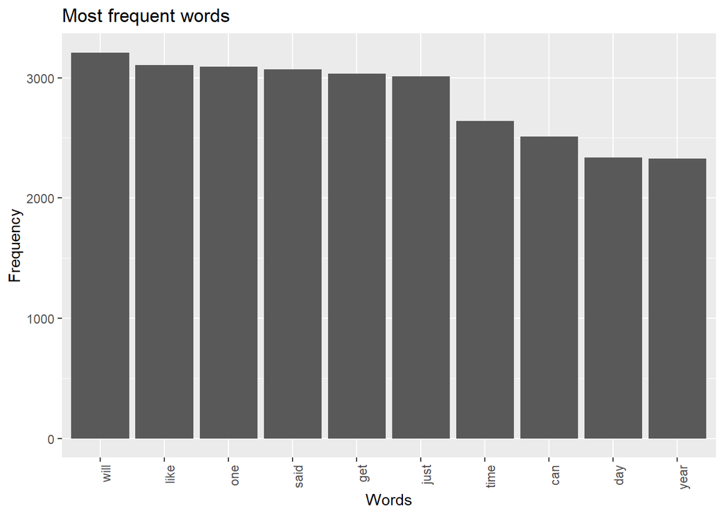

- *For 2-Grams*:

  | 2-Gram | Frequency |
  | --- | --- |
  | right now | 241 |
  | year old | 227 |
  | look like | 225 |
  | last year | 219 |
  | cant wait | 199 |
  | feel like | 190 |
  | dont know | 187 |
  | new york | 186 |
  | im go | 167 |
  | year ago | 156 |

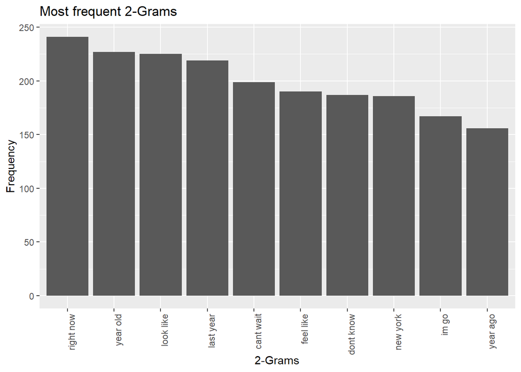

- *For 3-Grams*:

  | Word | Frequency |
  | --- | --- |
  | cant wait see | 30 |
  | happi mother day | 29 |
  | let us know | 29 |
  | presid barack obama | 26 |
  | new york citi | 24 |
  | look forward see | 23 |
  | happi new year | 22 |
  | dont even know | 19 |
  | two year ago | 17 |
  | st loui counti | 16 |

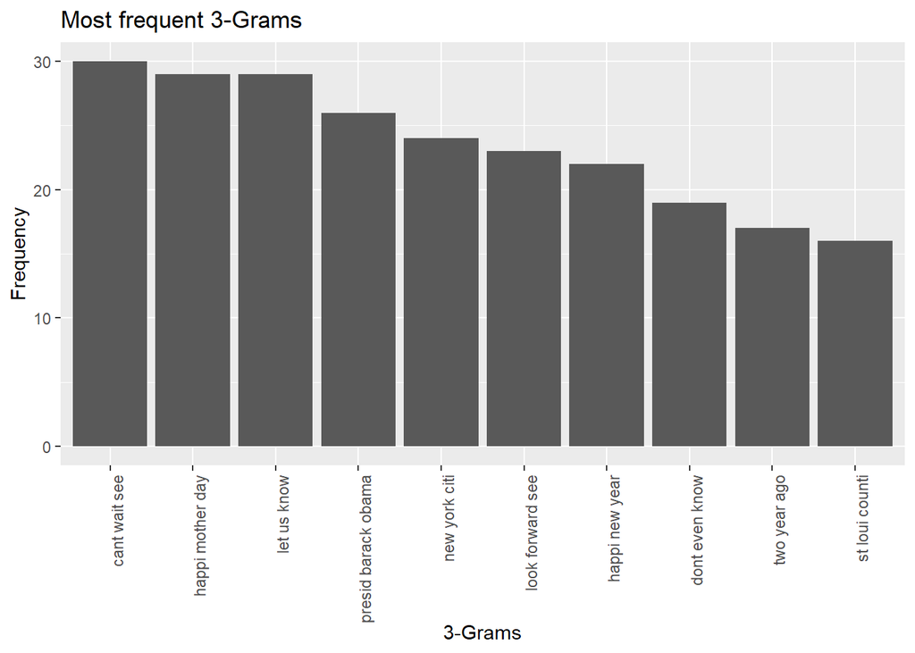

Next, the follwing questions from the [*Task 2*](https://www.coursera.org/learn/data-science-project/supplement/BePVz/task-2-exploratory-data-analysis) are answered:

- *How many unique words do you need in a frequency sorted dictionary to cover 50% of all word instances in the language? 90%?*

Taking the advantage of already having the word frequencies (descending ordered), we can iterate over them and get the total amount of unique words and word instances:

*Word instances:*

```
## [1] 403637
```

*Unique words:*

```
## [1] 2004
```

With this data, the amount of unique words for a coverge of 50% is *286*, and for 90% is *1328*.

- *How do you evaluate how many of the words come from foreign languages?*

```r
# Return a data frame with 2 column, word and valid (TRUE for words in English, FALSE otherwise)
detectNonEnglishWords <- function(line) {

  convertWord <- function(word) iconv(word, 'ISO8859-1', 'ASCII', sub = '<NON_ENGLISH_LETTER>')

  isNotConvertedWord <- function(word) !str_detect(convertWord(word), '<NON_ENGLISH_LETTER>')

  wordsInLine <- str_split(line, boundary("word"))[[1]]
  wordsDF <- data.frame(word = wordsInLine)
  wordsDF <- wordsDF %>%
    rowwise() %>%
    mutate(valid = isNotConvertedWord(word))

  wordsDF
}
```

```r
originalText <- 'The Fu�ball is the King of Sports'
originalText
```

```
## [1] "The Fu�ball is the King of Sports"
```

```r
detectNonEnglishWords('The Fu�ball is the King of Sports')
```

```
## # A tibble: 10 x 2
## # Rowwise:
##    word   valid
##    <chr>  <lgl>
##  1 The    TRUE
##  2 Fu     TRUE
##  3 U      TRUE
##  4 FFFD   TRUE
##  5 ball   TRUE
##  6 is     TRUE
##  7 the    TRUE
##  8 King   TRUE
##  9 of     TRUE
## 10 Sports TRUE
```

```r
# Remove non-english words from a line of text
removeNonEnglishWords <- function(line) {
  wordsDF <- detectNonEnglishWords(line)
  filteredLine <- paste(wordsDF[wordsDF$valid == TRUE, 'word']$word, collapse = " ")
  filteredLine
}

originalText <- 'The Fu�ball is the King of Sports'
originalText
```

```
## [1] "The Fu�ball is the King of Sports"
```

```r
removeNonEnglishWords('The Fu�ball is the King of Sports')
```

```
## [1] "The Fu U FFFD ball is the King of Sports"
```

### 3.2) Further steps

The next steps of the project will be to build a predictive algorithm using N-Grams lookups, in order to compute probabilites for the next occurence regarding to the previous words, backing off to a lower level (e.g. from 3-gram to 2-gram, and so forth) as needed. Later, developing a web app (using [*Shiny*](https://shiny.rstudio.com/)) that uses such algorithm, suggesting to the user the next word.

## Appendix I - Source codes

This document has been generated using [*R Mardown*](http://rmarkdown.rstudio.com/). Its *.Rmd* source code that can be found at: https://github.com/ShubhenduDash/DataScienceCapstone.